# The Pixar Formula

Pixar Animation Studios is an American CGI film production company that has produced 26 feature films, the first one being the 1995 classic, Toy Story. And although each story is unique, all of their movies are incredibly successful.

In this project, inspired by Data Camp, I will discuss the *'Pixar formula'* while using NLP (Natural Language Processing) to find the degree of similarity between movies based on their plots available on IMDb and Wikipedia, and create a dendrogram to represent how closely the movies are related to each other.

In addition, we will try to find plot patterns based on the division of clusters so that we can better understand the most common subjects that these films address and that make them so well received by the audience.

```python
import numpy as np
import pandas as pd
import nltk
import re

from nltk.stem.snowball import SnowballStemmer
from sklearn.feature_extraction.text import TfidfVectorizer
from sklearn.cluster import KMeans
from sklearn.metrics import silhouette_samples, silhouette_score

# Import cosine_similarity to calculate similarity of movie plots
from sklearn.metrics.pairwise import cosine_similarity

# Import matplotlib.pyplot for plotting graphs
import matplotlib.pyplot as plt

# Configure matplotlib to display the output inline
%matplotlib inline

# Import modules necessary to plot dendrogram
from scipy.cluster.hierarchy import linkage, dendrogram

# Set seed for reproducibility
np.random.seed(5)

movies_df = pd.read_excel('./pixar.xlsx')
```

```python
nltk.download('punkt')
nltk.download('averaged_perceptron_tagger')
```

```
True
```

```python
print("Number of movies loaded: %s " % len(movies_df))
```

```
Number of movies loaded: 26
```

#### Combine Wikipedia and IMDB plot summaries

The dataset we imported currently contains two columns titled wiki_plot and imdb_plot. They are the plot found for the movies on Wikipedia and IMDb, respectively. The text in the two columns is similar, however, they are often written in different tones and thus provide context on a movie in a different manner of linguistic expression. Further, sometimes the text in one column may mention a feature of the plot that is not present in the other column.

Let's combine both the columns to avoid the overheads in computation associated with extra columns to process.

```python
# combine wiki_plot and imdb_plot into a single column# combine wiki_plot and imdb_plot into a single column
movies_df['plot'] = movies_df['wiki_plot'].astype(str) + "\n" + movies_df['imdb_plot'].astype(str)

movies_df.head()
```

|  | title | imdb_plot | wiki_plot | imdb_rating | runtime_minutes | year | genres | num_votes | release_date | directors | plot |
| --- | --- | --- | --- | --- | --- | --- | --- | --- | --- | --- | --- |
| 0 | Toy Story | A cowboy doll is profoundly threatened and jea... | A group of anthropomorphic toys, who assume li... | 83 | 81 | 1995 | Animation, Adventure, Comedy, Family, Fantasy | 973962 | 1995-11-19 | John Lasseter | A group of anthropomorphic toys, who assume li... |
| 1 | A Bug's Life | A misfit ant, looking for "warriors" to save h... | A colony of ants, led by the elderly Queen and... | 72 | 95 | 1998 | Animation, Adventure, Comedy, Family, Fantasy | 289190 | 1998-11-14 | Andrew Stanton, John Lasseter | A colony of ants, led by the elderly Queen and... |
| 2 | Toy Story 2 | When Woody is stolen by a toy collector, Buzz ... | Andy Davis is preparing to go to cowboy camp w... | 79 | 92 | 1999 | Animation, Adventure, Comedy, Family, Fantasy | 571757 | 1999-11-13 | John Lasseter, Lee Unkrich, Ash Brannon | Andy Davis is preparing to go to cowboy camp w... |
| 3 | Monsters, Inc. | In order to power the city, monsters have to s... | In a world inhabited by monsters, the city of ... | 81 | 92 | 2001 | Animation, Adventure, Comedy, Family, Fantasy | 891853 | 2001-10-28 | David Silverman, Pete Docter, Lee Unkrich | In a world inhabited by monsters, the city of ... |
| 4 | Finding Nemo | After his son is captured in the Great Barrier... | Marlin is a clownfish who lives in an anemone ... | 82 | 100 | 2003 | Animation, Adventure, Comedy, Family | 1025788 | 2003-05-18 | Andrew Stanton, Lee Unkrich | Marlin is a clownfish who lives in an anemone ... |

#### Tokenization

Tokenization is the process by which we break down articles into individual sentences or words, as needed. First, lets take off the names of the characters. This might not be a problem for ou similarity analisys, but it would clean up the data for out most commom tokens analisys. The method I'm using to do this is a simple regular expression that identifies a upper case word plus the whitespaces before and after. The down side of this is that we are also deleting words after pontuations, but as they are mostly transition words with no significant meaning, I don't think it will affect tha analysis. Also, besides the tokenization method provided by NLTK, we might have to perform additional filtration to remove tokens which are entirely numeric values or punctuation.

```python
# Delete names
movies_df['plot'] = movies_df['plot'].apply(lambda x: re.sub(r"\s*[A-Z]\w*\s*", " ", x).strip())
```

#### Stemming

Stemming is the process by which we bring down a word from its different forms to the root word. This helps us establish meaning to different forms of the same words without having to deal with each form separately. For example, the words 'fishing', 'fished', and 'fisher' all get stemmed to the word 'fish'.

There are different algorithms available for stemming such as the Porter Stemmer, Snowball Stemmer, etc. We shall use the Snowball Stemmer.

```python
# Define a function to perform both stemming and tokenization
stemmer = SnowballStemmer("english")

def tokenize_and_stem(text):

    # Tokenize by sentence, then by word
    tokens = [word for text in nltk.sent_tokenize(text) for word in nltk.word_tokenize(text)]
    # Filter out raw tokens to remove noise
    filtered_tokens = [token for token in tokens if re.search('[a-zA-Z]', token)]

    # Stem the filtered_tokens
    stems = [stemmer.stem(word) for word in filtered_tokens]

    return stems
```

#### Create TfidfVectorizer

Computers do not understand text. These are machines only capable of understanding numbers and performing numerical computation. Hence, we must convert our textual plot summaries to numbers for the computer to be able to extract meaning from them. One simple method of doing this would be to count all the occurrences of each word in the entire vocabulary and return the counts in a vector. Enter CountVectorizer.

Consider the word 'the'. It appears quite frequently in almost all movie plots and will have a high count in each case. But obviously, it isn't the theme of all the movies! Term Frequency-Inverse Document Frequency (TF-IDF) is one method which overcomes the shortcomings of CountVectorizer. The Term Frequency of a word is the measure of how often it appears in a document, while the Inverse Document Frequency is the parameter which reduces the importance of a word if it frequently appears in several documents.

In simplest terms, TF-IDF recognizes words which are unique and important to any given document. Let's create one for our purposes.

```python
# Instantiate TfidfVectorizer object with stopwords and tokenizer parameters for efficient processing of text
tfidf_vectorizer = TfidfVectorizer(max_df=0.8, max_features=200000,
                                 min_df=0.2, stop_words='english',
                                 use_idf=True, tokenizer=tokenize_and_stem,
                                 ngram_range=(1,3))
```

#### Fit transform TfidfVectorizer

Once we create a TF-IDF Vectorizer, we must fit the text to it and then transform the text to produce the corresponding numeric form of the data which the computer will be able to understand and derive meaning from. To do this, we use the fit_transform() method of the TfidfVectorizer object.

```python
tfidf_matrix = tfidf_vectorizer.fit_transform([x for x in movies_df["plot"]])

print(tfidf_matrix.shape)
```

```
(26, 188)
```

#### Import KMeans and create clusters

To determine how closely one movie is related to the other by the help of unsupervised learning, we can use clustering techniques. Clustering is the method of grouping together a number of items such that they exhibit similar properties. According to the measure of similarity desired, a given sample of items can have one or more clusters.

K-means is an algorithm which helps us to implement clustering in Python. The name derives from its method of implementation: the given sample is divided into K clusters where each cluster is denoted by the mean of all the items lying in that cluster.

Certain factors can impact the efficacy of the final clusters formed when using k-means clustering, the main one being the number of clusters. To determine the optimal number, we are going to compare two different methods: Elbow Curve and Silhouette analysis.

###### Ebow Curve Method

The elbow method runs k-means clustering on the dataset for a range of values of k (say 1 to 10); Perform K-means clustering with all these different values of K. For each of the K values, we calculate average distances to the centroid across all data points and plot these points and find the point where the average distance from the centroid falls suddenly (“Elbow”).

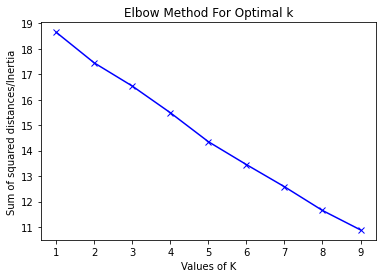

```python
sum_of_squared_distances = []
K = range(1, 10)
for num_clusters in K :
    kmeans = KMeans(n_clusters=num_clusters)
    kmeans.fit(tfidf_matrix)
    sum_of_squared_distances.append(kmeans.inertia_)

plt.plot(K,sum_of_squared_distances,'bx-')
plt.xlabel('Values of K')
plt.ylabel('Sum of squared distances/Inertia')
plt.title('Elbow Method For Optimal k')
plt.show()
```

Although not so clear, we can see that the optimal number of clusters should be around 4.

##### Silhouette analysis

The silhouette coefficient is a measure of how similar a data point is within-cluster (cohesion) compared to other clusters (separation). The function selects a range of values of k and plot Silhouette coefﬁcient for each value of K.

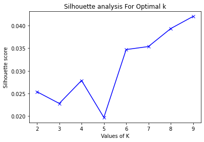

```python
range_n_clusters = [2, 3, 4, 5, 6, 7, 8, 9]
silhouette_avg = []
for num_clusters in range_n_clusters:
    # initialise kmeans
    kmeans = KMeans(n_clusters=num_clusters)
    kmeans.fit(tfidf_matrix)
    cluster_labels = kmeans.labels_

    # silhouette score
    silhouette_avg.append(silhouette_score(tfidf_matrix, cluster_labels))


plt.plot(range_n_clusters,silhouette_avg,'bx-')
plt.xlabel('Values of K')
plt.ylabel('Silhouette score')
plt.title('Silhouette analysis For Optimal k')
plt.show()
```

We see that the silhouette score is maximized at k = 9, but similar to our Elbow method, is also locally maximized with k=4, so we'll go with that, since que have a very small dataset (26 points/movies).

```python
NUM_CLUSTERS = 4
```

```python
# Create a KMeans object with 'NUM_CLUSTERS' clusters and save as km
km = KMeans(n_clusters=NUM_CLUSTERS)

# Fit the k-means object with tfidf_matrix
km.fit(tfidf_matrix)

clusters = km.labels_.tolist()

# Create a column cluster to denote the generated cluster for each movie
movies_df["cluster"] = clusters

# Display number of films per cluster (clusters from 0 to 4)
movies_df['cluster'].value_counts()
```

```
0    10
3     9
2     4
1     3
Name: cluster, dtype: int64
```

#### Calculate similarity distance

Now we are going to use our TF-IDF matrix to calculate the cosine angle formed between the vectors that represents the plots. If the vectors are similar, the cosine of their angle would be 1. The similarity distance is $1 - cosineangle$. IE, if we have two very similar plots, the distance between them would be 1-1 = 0.

```python
similarity_distance = 1 - cosine_similarity(tfidf_matrix)
```

```python
movies_df['lable'] = movies_df['title'] + ", " + movies_df['cluster'].map(str)
```

[figure not shown]

```python
# Create mergings matrix
mergings = linkage(similarity_distance, method='complete')

# Plot the dendrogram, using title as label column
dendrogram_ = dendrogram(mergings,
               labels=[x for x in movies_df["lable"]],
               leaf_rotation=90,
               leaf_font_size=12,
)

# Adjust the plot
fig = plt.gcf()
_ = [lbl.set_color('r') for lbl in plt.gca().get_xmajorticklabels()]
fig.set_size_inches(108, 21)

# Show the plotted dendrogram
plt.savefig("dendrogram1.png", dpi=300)
plt.show()
```

#### Most frequent tokens

The final step is to see if we can find some type of subject pattern in the movies plots, by each cluster.

```python
movies_df_test = movies_df.copy()
```

```python
movies_df_test['tokens'] = movies_df_test['plot'].apply(tokenize_and_stem)
```

```python
def tagging(text):
    pos_tagged = nltk.pos_tag(text)
    inp = [i for i in pos_tagged if 'NN' in i[1] ]  #nouns
    words = [i[0] for i in inp]
    return words
```

```python
frequent_tokens = {}
for i in range(0,NUM_CLUSTERS):
    name = str(i)
    frequent_tokens["Cluster "+ name] = []

frequent_tokens
```

```
{'Cluster 0': [], 'Cluster 1': [], 'Cluster 2': [], 'Cluster 3': []}
```

```python
NUM_TOKENS = 20
```

```python
def most_commom(df, dic):
    for i in range(0,NUM_CLUSTERS):
        cluster_df = df[df['cluster']==i]
        tags = cluster_df['tokens'].apply(tagging)
        tags_list = tags.tolist()
        flat_list = [val for sublist in tags_list for val in sublist]
        name = str(i)
        freq = nltk.FreqDist(flat_list).most_common(NUM_TOKENS)
        freq_list = [a[0] for a in freq]
        dic["Cluster "+ name] = freq_list
```

```python
most_commom(movies_df_test, frequent_tokens)
for key, value in frequent_tokens.items():
    print(key, ' : ', value)
```

```
Cluster 0  :  ['toy', 'race', 'truck', 'friend', 'car', 'escap', 'name', 'tri', 'gang', 'year', 'help', 'parent', 'plan', 'accident', 'bird', 'home', 'road', 'mother', 'way', 'fall']
Cluster 1  :  ['panda', 'friend', 'memori', 'fuel', 'core', 'time', 'year', 'island', 'discov', 'form', 'school', 'parent', 'ship', 'emot', 'night', 'person', 'caus', 'hyperspac', 'tri', 'dure']
Cluster 2  :  ['famili', 'superhero', 'soul', 'life', 'bodi', 'discov', 'badg', 'photo', 'jazz', 'suit', 'control', 'music', 'realiz', 'play', 'spark', 'day', 'mission', 'power', 'action', 'intent']
Cluster 3  :  ['father', 'monster', 'home', 'restaur', 'children', 'return', 'clan', 'door', 'reveal', 'boy', 'plant', 'day', 'mother', 'famili', 'world', 'school', 'sea', 'brother', 'spell', 'arriv']
```

From this we can see that, even though we have 4 cluters, the similarities between them are very significant. Let's do the same exercise but for all movies together.

```python
tags = movies_df_test['tokens'].apply(tagging)
tags_list = tags.tolist()
flat_list = [val for sublist in tags_list for val in sublist]
freq = nltk.FreqDist(flat_list).most_common(NUM_TOKENS)
freq_list = [a[0] for a in freq]

freq_list
```

```
['toy',
 'race',
 'famili',
 'friend',
 'home',
 'time',
 'year',
 'life',
 'tri',
 'children',
 'father',
 'parent',
 'mother',
 'truck',
 'return',
 'discov',
 'day',
 'escap',
 'name',
 'attempt']
```

It seems that Pixar's formula basically involves exploring themes such as **family relationships** ('famili', 'children', 'father', 'parent', 'mother'), **friendship** ('friend'), **growing up** ('time', 'year', 'day', 'life') and **new discoveries ('discov', 'return', 'escap')**. These are themes we all go through and can relate to, so it's no surprise the consistent success these films have for audiences of all ages.